# STS 112: Lab 4

James Chapman

## Occupation

In our Notebook for this week, we worked with Industry variables, which indicate the sector of the economy in which a person was working. In the Lab, we will work with Occupation variables, which indicate the type of work a person was doing.

### Getting started

Start by loading the `tidyverse` package and reading in the Week 4 dataset.

```r
library(tidyverse)
```

```r
ipums <- read_csv("wk4.csv")
```

Make a new data frame called `working` that includes only men aged 15-64. Test to make sure you have done this correctly.

```r
working <- ipums %>% filter(SEX == 1 & AGE %in% 15:64)

table(working$SEX) #This shows that there are only men.
```

```
      1
1552888
```

```r
summary(working$AGE) #This shows that the ages range from 15 to 64.
```

```
   Min. 1st Qu.  Median    Mean 3rd Qu.    Max.
  15.00   23.00   32.00   34.28   44.00   64.00
```

```r
names(working) #This shows that all of the categories in the ipums dataframe are still present.
```

```
 [1] "YEAR"     "STATEFIP" "PERWT"    "SEX"      "AGE"      "RACE"     "RACED"    "OCC"      "OCC1950"  "IND1950"
```

### Classifying occupations

Create a new variable in your `working` data frame called `OCCUP` that classifies the values of OCC1950 into the following ten categories: Professional/Technical, Agricultural (including farmers, farm managers, and farm laborers), Managers/Officials/Proprietors, Clerical and Kindred, Sales workers, Craftsmen, Operatives, Service workers (including household and nonhousehold), Laborers, and None. This variable should be a factor, with labels indicating the names of the categories (you can abbreviate the names of the categories in the labels). Test to make sure you have done this correctly by making a scatterplot of `OCCUP` by `OCC1950`.

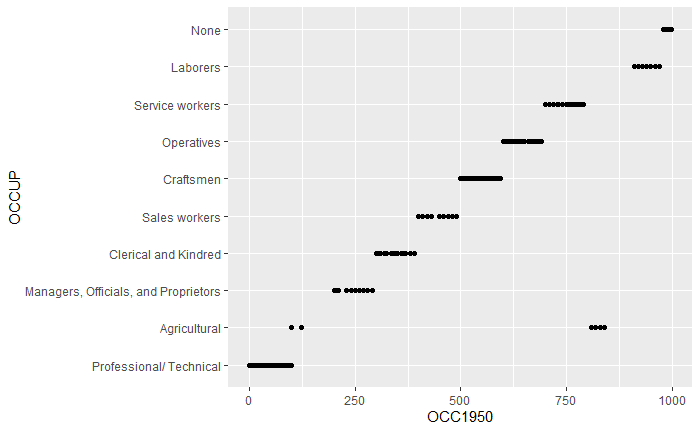

```r
working <- working %>% mutate(OCCUP = ifelse(OCC1950 <= 99, 1,
                       ifelse(OCC1950 <= 123 | OCC1950 %in% 810:840, 2,
                       ifelse(OCC1950 <= 290, 3,
                       ifelse(OCC1950 <= 390, 4,
                       ifelse(OCC1950 <= 490, 5,
                       ifelse(OCC1950 <= 595, 6,
                       ifelse(OCC1950 <= 690, 7,
                       ifelse(OCC1950 <= 790, 8,
                       ifelse(OCC1950 <= 970, 9, 10)))))))))) %>%
          mutate(OCCUP = factor(OCCUP,
                        labels = c("Professional/ Technical", "Agricultural", "Managers, Officials, and Proprietors", "Clerical and Kindred",
                                    "Sales workers", "Craftsmen", "Operatives", "Service workers", "Laborers", "None")))

qplot(OCCUP, OCC1950, data = working) + coord_flip()
```

Make a column graph, with `YEAR` on the x-axis, number of people on the y-axis, and `OCCUP` represented by fill. **Include all necessary layers to make this graph publication quality (meaningful title, labels on x- and y-axes, axes formatted, label on legend).** Hint: Find where we did something similar in the Notebook, then copy/paste and edit the code.

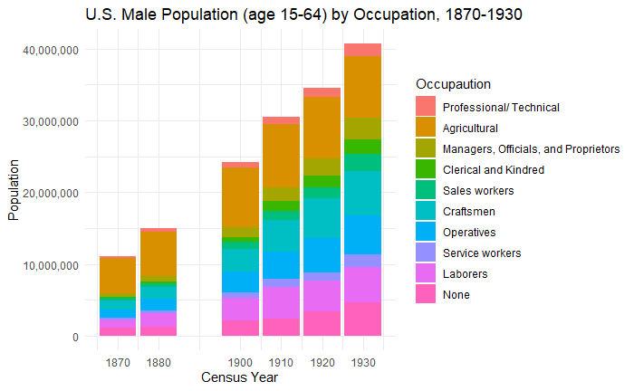

```r
working %>% group_by(YEAR, OCCUP) %>% count(wt = PERWT) %>%
  ggplot(aes(YEAR, n, fill = OCCUP)) +
    geom_col() +
    scale_x_continuous(breaks = c(1870, 1880, 1900, 1910, 1920, 1930)) +
    scale_y_continuous(labels = scales::comma) +
    theme_minimal() +
    labs(x = "Census Year", y = "Population", fill = "Occupaution", title = "U.S. Male Population (age 15-64) by Occupation, 1870-1930")
```

## Race and work

The reading for this week suggested that working experience differed depending on race. We are going to make the plot again, faceting by race. We will start by creating a new variable in the `working` data frame called `RACEF` that contains the following categories: White, Black, Native, Other. This variable should be a factor with labels giving the title of each category.

```r
working <- working %>% mutate(RACEF = ifelse(RACE == 1, 1,
                                      ifelse(RACE == 2, 2,
                                      ifelse(RACE == 3, 3, 4)))) %>%
          mutate(RACEF = factor(RACEF,
                        labels = c("White", "Black", "Native", "Other")))
```

Make a scatterplot of `RACEF` by `RACE` to make sure you classified everyone as you intended.

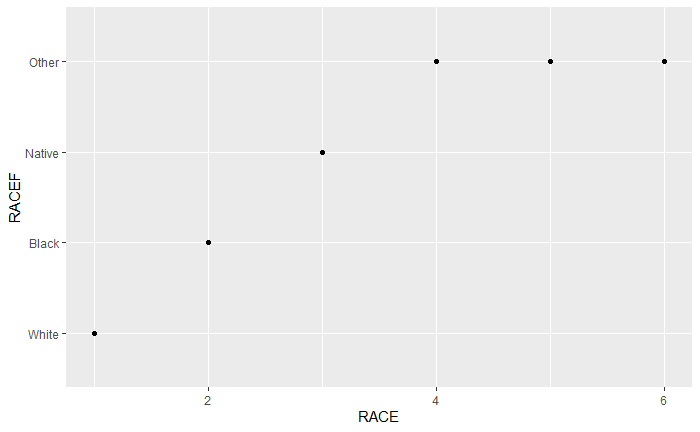

```r
qplot(RACEF, RACE, data = working) + coord_flip()
```

Plot `OCCUP` again, faceting by `RACEF`.

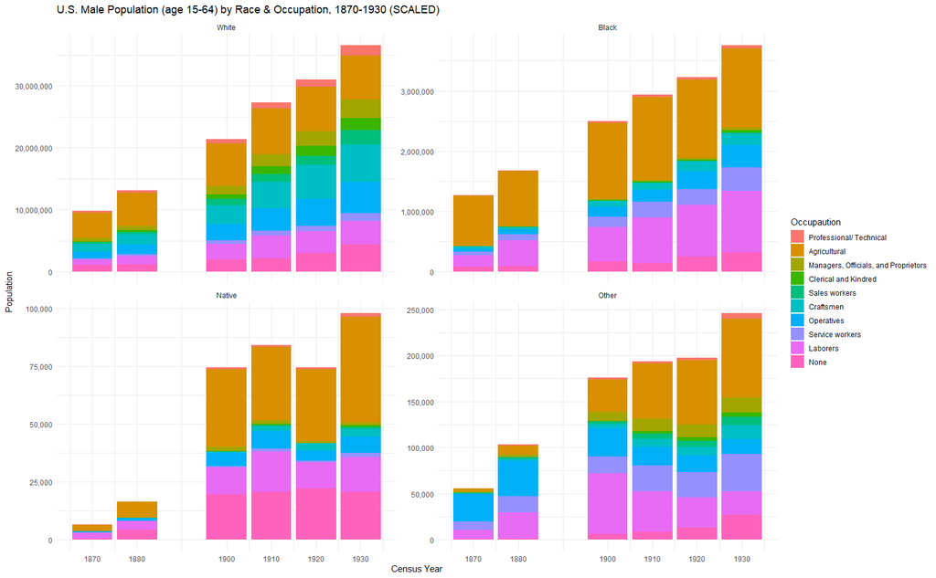

```r
working %>% group_by(YEAR, OCCUP, RACEF) %>% count(wt = PERWT) %>%
  ggplot(aes(YEAR, n, fill = OCCUP)) +
    geom_col() +
    facet_wrap(vars(RACEF), scales = "free_y") +
    scale_x_continuous(breaks = c(1870, 1880, 1900, 1910, 1920, 1930)) +
    scale_y_continuous(labels = scales::comma) +
    theme_minimal() +
    labs(x = "Census Year", y = "Population", fill = "Occupaution", title = "U.S. Male Population (age 15-64) by Race & Occupation, 1870-1930 (SCALED)")
```

## Thinking about race and region

We saw in the Notebook that different regions of the country had different types of industry. Is it possible that the racial differences we see in the above graph are related to region? Add a `REGION` variable to the data frame (just like in the notebook) and plot the population by `RACEF` and `REGION` (one as the fill variable and one as the facet variable, with `YEAR` on the x-axis and total population on the y-axis). Make the graph publication quality and be sure it has the correct labels.

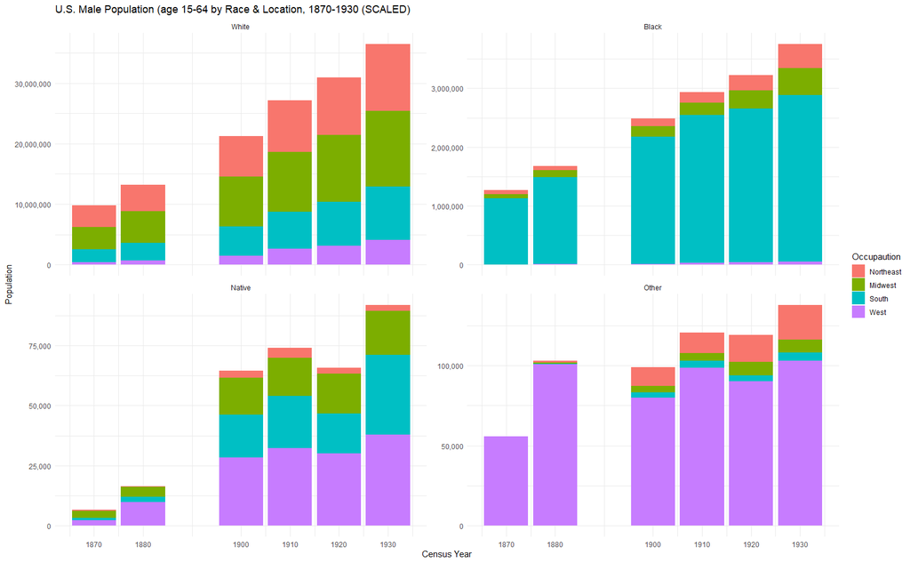

```r
northeast <- c(9, 23, 25, 33, 44, 50, 34, 36, 42)
midwest <- c(17, 18, 26, 39, 55, 19, 20, 27, 29, 31, 38, 46)
south <- c(10, 11, 12, 13, 24, 37, 45, 51, 54, 1, 21, 28, 47, 5, 22, 40, 48)
west <- c(4, 8, 16, 30, 32, 35, 49, 56, 6, 41, 53)

working <- working %>% mutate(REGION = ifelse(STATEFIP %in% northeast, 1,
                                   ifelse(STATEFIP %in% midwest, 2,
                                   ifelse(STATEFIP %in% south, 3,
                                   ifelse(STATEFIP %in% west, 4, 0))))) %>%
  filter(REGION > 0) %>% mutate(REGION = factor(REGION, labels = c("Northeast", "Midwest", "South", "West")))

working %>% group_by(YEAR, REGION, RACEF) %>% count(wt = PERWT) %>%
  ggplot(aes(YEAR, n, fill = REGION)) +
    geom_col() +
    facet_wrap(vars(RACEF), scales = "free_y") +
    scale_x_continuous(breaks = c(1870, 1880, 1900, 1910, 1920, 1930)) +
    scale_y_continuous(labels = scales::comma) +
    theme_minimal() +
    labs(x = "Census Year", y = "Population", fill = "Occupaution", title = "U.S. Male Population (age 15-64 by Race & Location, 1870-1930 (SCALED)")
```

Now plot `OCCUP` as the fill variable, faceting horizontally (rows) by `RACEF` and vertically (columns) by `REGION`. Remember that all graphs must be publication quality.

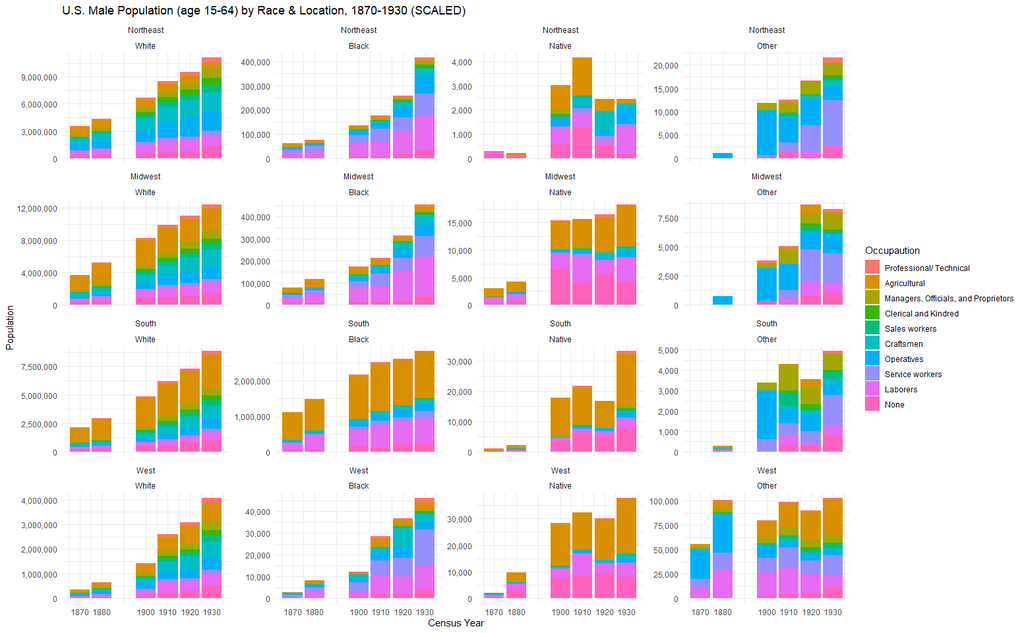

```r
working %>% group_by(YEAR, REGION, RACEF, OCCUP) %>% count(wt = PERWT) %>%
  ggplot(aes(YEAR, n, fill = OCCUP)) +
    geom_col() +
    facet_wrap(vars(REGION, RACEF), scales = "free_y") +
    scale_x_continuous(breaks = c(1870, 1880, 1900, 1910, 1920, 1930)) +
    scale_y_continuous(labels = scales::comma) +
    theme_minimal() +
    labs(x = "Census Year", y = "Population", fill = "Occupaution", title = "U.S. Male Population (age 15-64) by Race & Location, 1870-1930 (SCALED)")
```

## Turn in this assignment

Click `Preview` to make sure your lab looks the way you want it to. Upload the `Lab4.nb.html` file to Canvas.